# Market Timing Strategy Based on HMM Model

#### — Unsupervised learing applied on stock market

### **Cheng Ximen, CFA, FRM**

**list of content**

1. Introduciton
2. Modeling
3. Strategy Development

If you do not wish to see the raw code in this report please click the button below

```python
%%HTML
<button onclick="$('.input, .prompt, .output_stderr, .output_error, .output_result').toggle();">Hide Code</button>
```

## 1. Introduction

**Background for this report**

In view of the progress of my research in developing quantative investment algorithm, this report can be seen as a sequel to the resistance and support index report, with the ideology behind that report and my early algorithms developed being to interpret the most famous traditional investment strategies, which can be either technical or fundamental, as a set of rules that computer can follow and are easy for us to evaluate through back testing. As I’m scratching my head trying to come up with a better strategy to outperform the market, it dawned on me that if this is essentially a statistical problem, maybe statistical modeling can find some hidden rules which are not easy to grasp by human intuition and there’s no better tool in terms of finding patterns than machine learning and AI, which are now so easily available thanks to the great open source community. Even though I had academic training in econometrics and experience in building logistic model to predict the likelihood of default in auto loans during my first job, it still took me a while to go through and get familiar with all the major ML algorithms including SVM, Ensemble Tree Models, KNN, PCA, DNN and etc. Through further research I find this a far more promising direction then my old way of trying to find a good strategy by inspiration. This report is one of the results in my attempts to use statistical model to find hidden rules in financial market.

## 2. Modeling

**Index and Data**

```python
# import libraries

import pandas as pd
import numpy as np
import seaborn as sns
import matplotlib.pyplot as plt
%matplotlib inline
from sklearn.metrics import accuracy_score, roc_auc_score, precision_score, recall_score,confusion_matrix,make_scorer
from sklearn.preprocessing import StandardScaler, MinMaxScaler
from sklearn.model_selection import TimeSeriesSplit
import scikitplot
import warnings
warnings.filterwarnings('ignore')
```

The index we chose to do formulate and test our model is CSI300, same as last report. I've already done some feature engenieering beforehand. They are mainly price related features, with the main reasoning behind being, as can be seen in the last report it's possible to achieve a pretty decent return simply by devising a trend related technical indicator. If statistical modeling method works, the back testing result should be at least as good as the technical indicator.

```python
df = pd.read_csv('300_features.csv',index_col=0)
df = df.dropna()

pd.set_option("display.max_columns", 999)
df.head()
```

|  | open | close | high | low | volume | rsrs | rsrs_buy_status | close_5_MA | close/MA_5 | close_10_MA | close/MA_10 | close_20_MA | close/MA_20 | close_60_MA | close/MA_60 | volume_5_MA | volume/MA_5 | volume_10_MA | volume/MA_10 | volume_20_MA | volume/MA_20 | past_1_days_return | past_5_days_return | past_10_days_return | past_20_days_return | past_60_days_return | past_120_days_return | future_5_days_return | future_5_days_return_status | … |
| --- | --- | --- | --- | --- | --- | --- | --- | --- | --- | --- | --- | --- | --- | --- | --- | --- | --- | --- | --- | --- | --- | --- | --- | --- | --- | --- | --- | --- | --- | --- |
| 2009-11-11 | 3500.59 | 3495.67 | 3514.83 | 3468.86 | 7.262632e+09 | -1.153954 | 0.0 | 3488.516 | 1.002051 | 3425.212 | 1.020570 | 3381.4170 | 1.033788 | 3222.835000 | 1.084657 | 8.156326e+09 | 0.890429 | 7.816063e+09 | 0.929193 | 7.506559e+09 | 0.967505 | -0.002315 | 0.012097 | 0.049962 | 0.083123 | -0.017071 | 0.250186 | 0.038493 | 1 | … |
| 2009-11-12 | 3506.95 | 3499.99 | 3529.06 | 3487.68 | 7.996266e+09 | -1.209681 | 0.0 | 3495.650 | 1.001242 | 3450.506 | 1.014341 | 3394.4345 | 1.031097 | 3224.544833 | 1.085421 | 8.142624e+09 | 0.982026 | 8.002636e+09 | 0.999204 | 7.603562e+09 | 1.051647 | 0.001236 | 0.010296 | 0.077898 | 0.080364 | 0.030197 | 0.245295 | 0.040700 | 1 | … |
| 2009-11-13 | 3489.54 | 3518.72 | 3518.89 | 3445.36 | 9.121017e+09 | -1.148836 | 0.0 | 3502.790 | 1.004548 | 3474.341 | 1.012773 | 3408.2850 | 1.032402 | 3225.843167 | 1.090791 | 8.123021e+09 | 1.122860 | 8.308267e+09 | 1.097824 | 7.781432e+09 | 1.172151 | 0.005351 | 0.010250 | 0.072659 | 0.085452 | 0.022640 | 0.238951 | 0.031912 | 1 | … |
| 2009-11-16 | 3541.05 | 3625.80 | 3625.89 | 3541.05 | 1.231573e+10 | -1.117049 | 0.0 | 3528.792 | 1.027490 | 3497.641 | 1.036642 | 3423.1170 | 1.059210 | 3230.532167 | 1.122354 | 9.025149e+09 | 1.364602 | 8.720028e+09 | 1.412350 | 8.008803e+09 | 1.537774 | 0.030432 | 0.037190 | 0.068675 | 0.089104 | 0.084121 | 0.289008 | 0.010952 | 1 | … |
| 2009-11-17 | 3644.96 | 3628.35 | 3649.42 | 3619.99 | 9.739137e+09 | -0.837503 | 0.0 | 3553.706 | 1.021005 | 3516.933 | 1.031680 | 3435.6560 | 1.056087 | 3238.666833 | 1.120322 | 9.286957e+09 | 1.048690 | 8.856031e+09 | 1.099718 | 8.048628e+09 | 1.210037 | 0.000703 | 0.035553 | 0.056156 | 0.074249 | 0.155426 | 0.319395 | -0.022123 | 0 | … |

```python
df.columns
```

```
Index(['open', 'close', 'high', 'low', 'volume', 'rsrs', 'rsrs_buy_status',
       'close_5_MA', 'close/MA_5', 'close_10_MA', 'close/MA_10', 'close_20_MA',
       'close/MA_20', 'close_60_MA', 'close/MA_60', 'volume_5_MA',
       'volume/MA_5', 'volume_10_MA', 'volume/MA_10', 'volume_20_MA',
       'volume/MA_20', 'past_1_days_return', 'past_5_days_return',
       'past_10_days_return', 'past_20_days_return', 'past_60_days_return',
       'past_120_days_return', 'future_5_days_return',
       'future_5_days_return_status', 'future_10_days_return',
       'future_10_days_return_status', 'future_20_days_return',
       'future_20_days_return_status', 'macd', 'macd_signal', 'macd_hist',
       'RSI', '20_day_max', '10_day_min', 'close/20_day_max',
       'close/10_day_min', 'day_index'],
      dtype='object')
```

**Further data processing**

Most machine learning models don't do well with highly skewed dataset or dataset with different scales, so I did some log tranformation of the return featurs and normalization of other numerical features. And according to the research I've done before, the absolute value features don't perform as good as relative value features, for example 5 days moving average data is less informative then close devided by 5 days moving average, so I deleted those absolute value features from the features dataset.

```python
df_processed = df.copy()

future_col = ['future_5_days_return',
#              'future_5_days_return_status',
             'future_10_days_return',
             'future_10_days_return_status',
             'future_20_days_return',
             'future_20_days_return_status']

abs_col = ['high','low','open','volume','close',
           'volume_10_MA',
            'volume_20_MA',
            'volume_5_MA',
            '10_day_min',
            '20_day_max',
             'close_10_MA',
             'close_20_MA',
             'close_5_MA',
             'close_60_MA'
          ]

save_col = set(df.columns) - set(future_col)-set(abs_col)

con_col = list(save_col - set(['rsrs_buy_status','future_5_days_return_status']))

log_col = ['past_10_days_return',
         'past_120_days_return',
         'past_20_days_return',
         'past_5_days_return',
         'past_60_days_return']

# log transform
df_processed[log_col] = np.log1p(df[log_col])

scaler = StandardScaler()
df_processed[con_col] = scaler.fit_transform(df_processed[con_col].values)
df_processed = df_processed[save_col]
```

**Beseline Estimate**

To show the full thought process, I think it is meaningful to show some failed research attempts. At first I tried to work out a model that can predict whether we can achieve a positive return in the next week. To evaluate the model,we'll need to know what it means to be a good prediction accuracy by setting a baseline estimate accuracy.

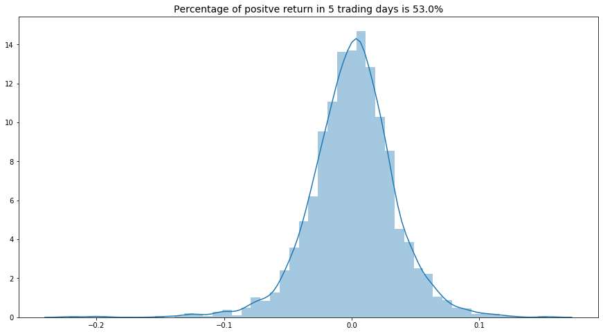

```python
plt.figure(figsize=(15, 8))
up_ratio = round(len(df[df.future_5_days_return_status==1])/len(df),2)
ax = sns.distplot(df.future_5_days_return, axlabel = False)
ax.set_title('Percentage of positve return in 5 trading days is {:.1%}'.format(up_ratio),fontsize=14)
plt.show()
```

Past 10 years return data shows that roughly 53% of the time, we’ll have cumulative 5 trading days return to be positive. I think it’s save to say that our model have no predictive power, if it’s accuracy is lower than 53%. It can be an interesting idea to use the trend index and strategy created in the last report as a model to see how it does in predicting the next week’s return. We assume that if the strategy says hold, it means the model predicts next week’s return to be positive and vice versa. And let’s plot out the confusion matrix.

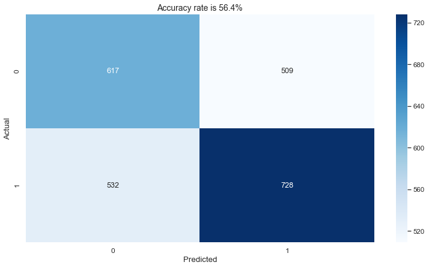

```python
def evaluate(true_series,pred_series):
    cm_data = confusion_matrix(true_series,pred_series)
    cm_df = pd.DataFrame(cm_data,index=[0,1],columns=[0,1])
    cm_df.index.name = 'Actual'
    cm_df.columns.name = 'Predicted'

    fig,ax = plt.subplots(figsize = (13,7))
    sns.set(font_scale=1.05)
    sns.heatmap(cm_df,annot=True,cmap='Blues',fmt='d',ax = ax)
    ax.set_title('Accuracy rate is {:.1%}'.format(accuracy_score(true_series,pred_series)),fontsize=14)
    ax.set_yticks(np.arange(3), minor=True)
    plt.show()

true_series = df.future_5_days_return_status
pred_series = df.rsrs_buy_status

evaluate(true_series,pred_series)
```

As you can see from the confusion matrix and the accuracy score, the simple model we created from the index in the last report only beat random choice by just a little bit, which means that even though it's a profitable strategy but it is not a good model to predict return for a fixed time frame. I thought then that the relationship between price and future return off course should be more complex than that. Maybe models better at handling nonlinear relationship among many features are better suited for this problem. It's time to take out the big guns! I tried various models to save the space I'll only keep Lightgbm and logistic regression below.

```python
from sklearn.linear_model import LogisticRegression
from lightgbm import LGBMClassifier
import scikitplot as skplt
```

```python
target_feature = 'future_5_days_return_status'
tscv = TimeSeriesSplit(n_splits=5)
x = df_processed.drop(columns=[target_feature])
y = df_processed[target_feature]

scorer = make_scorer(accuracy_score)
```

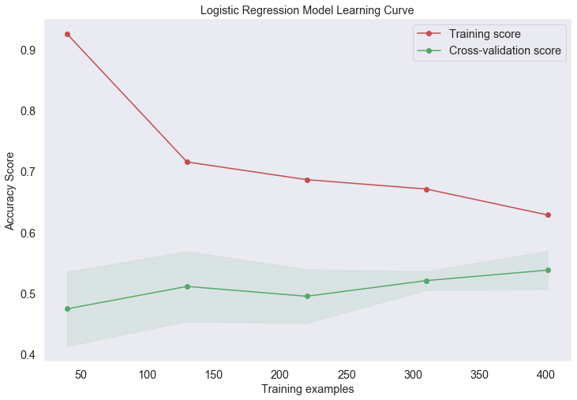

```python
clf_lr = LogisticRegression()
ax = skplt.estimators.plot_learning_curve(clf_lr,x.values,y.values,scoring=scorer,figsize=(12,8),
                                     random_state=24,cv = tscv)
ax.set_title('Logistic Regression Model Learning Curve')
ax.set_ylabel('Accuracy Score')
plt.show()
```

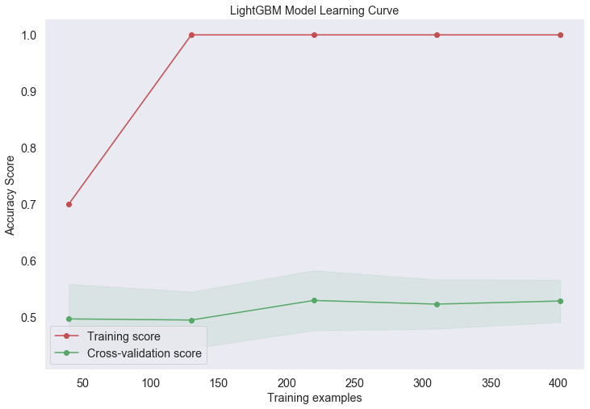

```python
clf_lgbm = LGBMClassifier()
ax = skplt.estimators.plot_learning_curve(clf_lgbm,x.values,y.values,scoring=scorer,figsize=(12,8),
                                     random_state=24,cv = tscv)
ax.set_title('LightGBM Model Learning Curve')
ax.set_ylabel('Accuracy Score')
plt.show()
```

From the learning curve chart above, we can see even LightBGM model is able to fit the data better than linear model like logistic as expected but it still can't do anything meaningful when facing out of sample data. With a few tweaks I guess we can improve the score by a few points, but it's still far from meeting our goal. And I start to ponder whether it's worth the time trying to predict the future return in a fixed period of time. I mean anything can happen to put off the bull market for another week. It seems I hit a dead end at this moment and that's when I bumped into the HMM model.

**HMM model**

I came to the news that HMM is one of the main models used by the most successful quantative fund Renaissance Institutional Equities Fund. Through further studys I found out that the model makes perfect sense in the stock market. I'll give a short description of my understanding of HMM model here. HMM is stemed from Marcov Chain model, which we uses unintentionally in our daily life all the time, such as when we are trying to bet on tail in flip coin bet, when it has been head the first 10 times before this. ([see this article](https://medium.com/@rohitpandey576/coin-toss-markov-chains-7995cb303406)). However when you see the tail comes up over 5 times you might think there's more chance that the game is rigged. That's the HMM way of thinking. In financial market, instead of trying to predict the future return, the better question to ask is what kind of market are we in right now. And we can use the features as the observations and the market condition as hidden state in HMM model. HMM model will tell us what market condition we are in by going through various technical indicators. It's so close to how a technical investor formulate it's trading strategy.

I used HMM model with Gaussian distribution with four hidden states. To save the time I'll skip trough the feature selection stage, which is basicly like how Edison invented light bulb by tring out different filament.

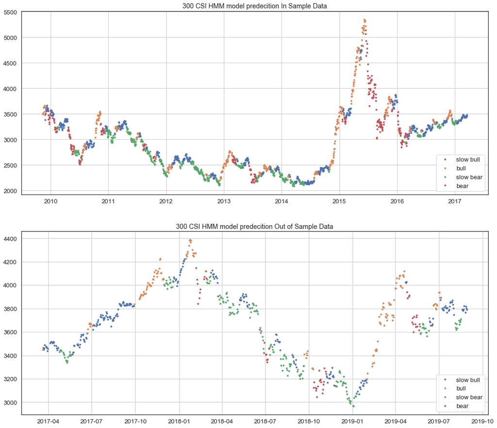

```python
from hmmlearn.hmm import GaussianHMM
from sklearn.decomposition import PCA
# select features
features_df = df_processed[['past_1_days_return','past_5_days_return','rsrs','RSI','close/MA_20','volume/MA_20']]
# add a PCA to rearrange the data a little more
pca = PCA(n_components=6)
pca.fit(features_df.values)
X = pca.transform(features_df.values)
# set aside training and test data
train_d = 600
hmm = GaussianHMM(n_components = 4,random_state=20, covariance_type='full',n_iter = 5000).fit(X[:-train_d])
# plot charts
datelist = pd.to_datetime(features_df.index[:-train_d])
closeidx = df[['close']][:-train_d]
sns.set_style('white')
dic = {
    0:'slow bull',
    1:'bull',
    2:'slow bear',
    3:'bear'
}

plt.figure(figsize = (18, 16))
ax1 = plt.subplot(211)
latent_states_sequence = hmm.predict(X[:-train_d])
datelist = pd.to_datetime(features_df.index[:-train_d])
closeidx = df[['close']][:-train_d]
for i in range(hmm.n_components):
    state = (latent_states_sequence == i)
    plt.plot(datelist[state],closeidx[state],'.',label = dic[i],lw = 1)
    plt.legend(loc = 'lower right')
    plt.grid(1)

ax1.set_title('300 CSI HMM model predecition In Sample Data')

latent_states_sequence = hmm.predict(X[-train_d:])
datelist = pd.to_datetime(features_df.index[-train_d:])
closeidx = df[['close']][-train_d:]
ax2 = plt.subplot(212)
for i in range(hmm.n_components):
    state = (latent_states_sequence == i)
    plt.plot(datelist[state],closeidx[state],'.',label = dic[i],lw = 1)
    plt.legend(loc = 'lower right')
    plt.grid(1)

ax2.set_title('300 CSI HMM model predecition Out of Sample Data')

plt.show()
```

## 3. Strategy Development

```python
def check_hold(labels,hold_status):
    # check inital holding status
    if hold_status == None:
        if labels[-1] in ['bull','slow bull']:
            return 1
        else:
            return 0
    else:
        if hold_status == 0:
            if labels[-1] == 'bull':
                return 1
            elif (sum(np.in1d(labels,['bull','slow bull']))/len(labels))>0.7:
                return 1
            else:
                return 0
        if hold_status == 1:
            if labels[-1] == 'bear':
                return 0
            elif (sum(np.in1d(labels,['bear','slow bear']))/len(labels))>0.7:
                return 0
            else:
                return 1
```

```python
labels = hmm.predict(X)
labels = pd.Series(labels).map(dic)
buy_ls = []
n = 10
for i in range(len(labels)):
    if i-n<0:
        if i == 0:
            buy_ls.append(check_hold(labels[0:i+1].values,None))
        else:
            buy_ls.append(check_hold(labels[0:i+1].values,buy_ls[-1]))
    else:
        buy_ls.append(check_hold(labels[i-n:i+1].values,buy_ls[-1]))
```

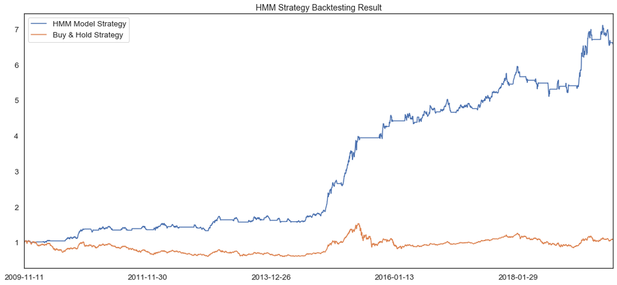

```python
backtest_df = pd.concat([(df.past_1_days_return*np.array(buy_ls)+1).cumprod(),(df.past_1_days_return+1).cumprod()],axis=1)
backtest_df.columns = ['HMM Model Strategy','Buy & Hold Strategy']
fig ,ax = plt.subplots(figsize = (18, 8))
backtest_df.plot.line(ax = ax)
ax.set_title('HMM Strategy Backtesting Result')
plt.show()
```

I would say the result looks really well considering we only used 6 price and volume related features. And I admit that the out of sample period after 2017 does look worse than in sample data. However considering this is essentially an unsupervised modeling approach, which means the model find the four hidden state by itself, I would argue it's less likely to overfit the data in the way we wanted. For further investigation, it might make sense to add more valuation and ecnomic data as features, which might have a stronger relationship with the medium to long term market condition. I'll leave it to the next report.